# Análise de Regressão

Author

Affiliation

[Prof. Dr. Juliano Bortolini](http://www.julianobortolini.com.br)

Universidade Federal de Mato Grosso

*Bacharelado em Estatística - UFMT*

## Prova 2

A Leishmaniose Visceral Canina (LVC) é uma zoonose causada pelo protozoário *Leishmania infantum* e transmitida por flebotomíneos, principalmente do gênero *Lutzomyia*. Os cães são os principais reservatórios domésticos da infecção, desempenhando papel central na cadeia de transmissão para seres humanos. A doença apresenta evolução crônica e multissistêmica, com manifestações clínicas diversas, como perda de peso, lesões dermatológicas, linfadenopatia, alterações oculares e comprometimento renal.

O tratamento utilizado neste estudo foi o Alopurinol. Esse medicamento atua inibindo a proliferação do parasito, promovendo melhora clínica e prolongando a sobrevida do animal, sendo uma das principais opções terapêuticas para o manejo da LVC.

### Coleta de Dados

Foram incluídos no estudo 17 cães diagnosticados com Leishmaniose Visceral Canina. Todos os animais foram submetidos exclusivamente ao tratamento com Alopurinol e acompanhados por um período inicial de 29 dias. As coletas de dados foram realizadas em dois momentos:

- **Tempo 0**: na data do diagnóstico da LVC;
- **Tempo 29**: 29 dias após o início do tratamento.

### Variáveis Coletadas

As seguintes variáveis foram registradas para cada animal:

- **Escore clínico**: medida semiquantitativa da gravidade clínica do animal, sendo que valores mais altos indicam maior comprometimento sistêmico.
- **IL-2 (pg/mL)**: concentração de interleucina 2, associada à resposta imune do tipo Th1 (imunidade celular).
- **IL-4 (pg/mL)**: concentração de interleucina 4, relacionada à resposta imune do tipo Th2 (imunidade humoral).
- **Plaquetas_ref**: se a contagem plaquetária, utilizada para avaliação de hemostasia e possíveis citopenias., é considerada normal (Sim) ou anormal (Não) com base nos valores de referência para cães (200-500 mil/mm³).
- **Leucócitos (mil/mm³)**: número total de leucócitos circulantes, indicando resposta inflamatória ou imunossupressão.
- **Albumina (g/dL)**: proteína sintetizada no fígado, indicadora do estado nutricional e de processos inflamatórios crônicos.

**Todos os dados são fictícios (simulados)!**

**Exercícios:**

1. Para as análises estatísticas, desenvolva uma explicação detalhada de cada etapa, incluindo a interpretação dos resultados e as conclusões que podem ser tiradas a partir dos testes realizados.
2. Sugira novas análises que poderiam ser realizadas com os dados disponíveis. Descreva quais testes ou modelos estatísticos seriam adequados para essas análises e justifique suas escolhas.

```r
mod_escore <- lm(Escore ~ Tempo + IL_2 + IL_4 +
                   Leucocitos +
                   Albumina + Plaquetas_ref, data = dados)
summary(mod_escore)
```

```
Call:
lm(formula = Escore ~ Tempo + IL_2 + IL_4 + Leucocitos + Albumina +
    Plaquetas_ref, data = dados)

Residuals:
    Min      1Q  Median      3Q     Max
-7.6677 -2.2145  0.0155  2.3682  5.8185

Coefficients:
                 Estimate Std. Error t value Pr(>|t|)
(Intercept)      28.65673    4.54605   6.304 9.54e-07 ***
Tempo            -0.12296    0.04198  -2.929 0.006833 **
IL_2             -0.36657    0.18159  -2.019 0.053561 .
IL_4              0.22563    0.11221   2.011 0.054428 .
Leucocitos       -0.41168    0.15483  -2.659 0.013016 *
Albumina         -5.15207    1.21399  -4.244 0.000231 ***
Plaquetas_refSim  1.57886    1.43818   1.098 0.281978
---
Signif. codes:  0 '***' 0.001 '**' 0.01 '*' 0.05 '.' 0.1 ' ' 1

Residual standard error: 3.435 on 27 degrees of freedom
Multiple R-squared:  0.5462,    Adjusted R-squared:  0.4454
F-statistic: 5.416 on 6 and 27 DF,  p-value: 0.0008761
```

```r
anova(mod_escore)
```

```
Analysis of Variance Table

Response: Escore
              Df Sum Sq Mean Sq F value    Pr(>F)
Tempo          1 136.00 136.000 11.5285 0.0021354 **
IL_2           1   6.86   6.861  0.5816 0.4522998
IL_4           1  18.79  18.792  1.5930 0.2176978
Leucocitos     1   8.16   8.160  0.6917 0.4128749
Albumina       1 199.34 199.337 16.8975 0.0003301 ***
Plaquetas_ref  1  14.22  14.218  1.2052 0.2819780
Residuals     27 318.51  11.797
---
Signif. codes:  0 '***' 0.001 '**' 0.01 '*' 0.05 '.' 0.1 ' ' 1
```

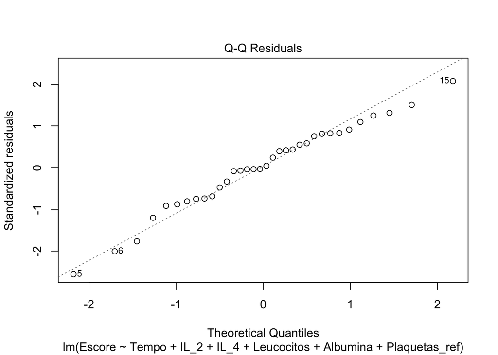

```r
plot(mod_escore, which = 2)
```

```r
shapiro.test(rstandard(mod_escore))
```

```
    Shapiro-Wilk normality test

data:  rstandard(mod_escore)
W = 0.9789, p-value = 0.7379
```

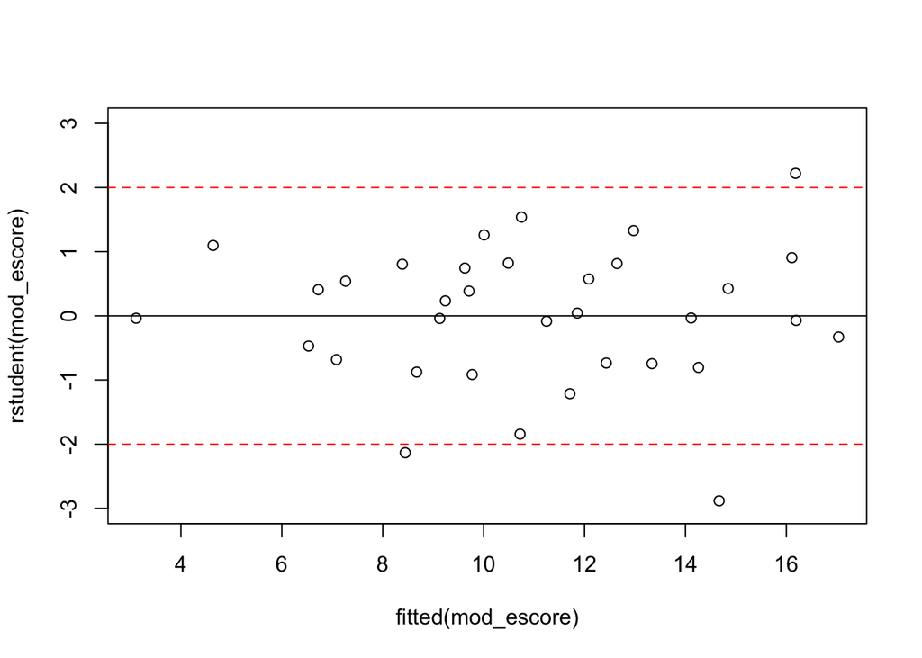

```r
plot(rstudent(mod_escore) ~ fitted(mod_escore), ylim = c(-3,3))
abline(h = 0, col = "black")
abline(h = 2, col = "red", lty = 2)
abline(h = -2, col = "red", lty = 2)
```

```r
lmtest::bptest(mod_escore)
```

```
    studentized Breusch-Pagan test

data:  mod_escore
BP = 11.489, df = 6, p-value = 0.07439
```

```r
mod_escore_2 <- lm(Escore ~ Tempo + Albumina, data = dados)
summary(mod_escore_2)
```

```
Call:
lm(formula = Escore ~ Tempo + Albumina, data = dados)

Residuals:
    Min      1Q  Median      3Q     Max
-7.0915 -2.4798  0.2509  2.4466  8.5515

Coefficients:
            Estimate Std. Error t value Pr(>|t|)
(Intercept) 20.47562    2.85330   7.176 4.56e-08 ***
Tempo       -0.11720    0.04578  -2.560   0.0156 *
Albumina    -3.19415    1.14411  -2.792   0.0089 **
---
Signif. codes:  0 '***' 0.001 '**' 0.01 '*' 0.05 '.' 0.1 ' ' 1

Residual standard error: 3.819 on 31 degrees of freedom
Multiple R-squared:  0.3557,    Adjusted R-squared:  0.3142
F-statistic: 8.559 on 2 and 31 DF,  p-value: 0.001097
```

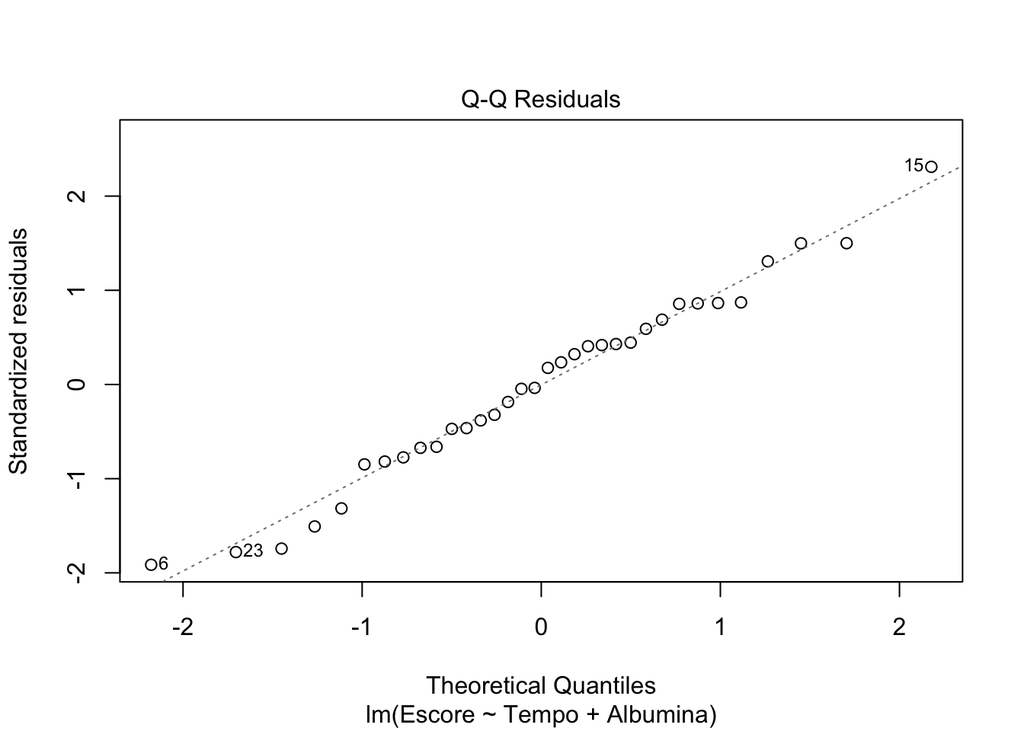

```r
plot(mod_escore_2, which = 2)
```

```r
shapiro.test(rstandard(mod_escore_2))
```

```
    Shapiro-Wilk normality test

data:  rstandard(mod_escore_2)
W = 0.98157, p-value = 0.8207
```

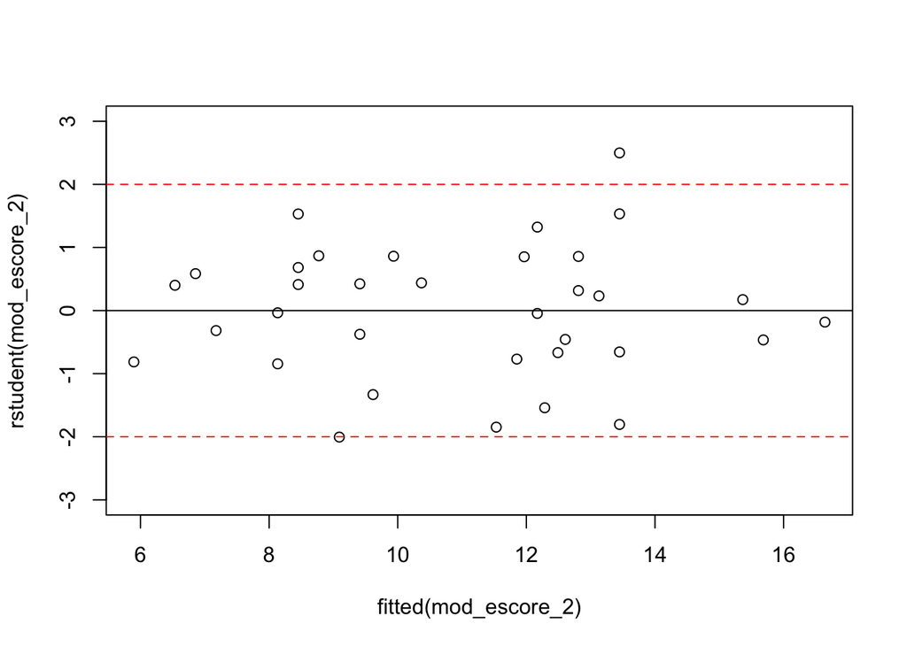

```r
plot(rstudent(mod_escore_2) ~ fitted(mod_escore_2), ylim = c(-3,3))
abline(h = 0, col = "black")
abline(h = 2, col = "red", lty = 2)
abline(h = -2, col = "red", lty = 2)
```

```r
lmtest::bptest(mod_escore_2)
```

```
    studentized Breusch-Pagan test

data:  mod_escore_2
BP = 1.1426, df = 2, p-value = 0.5648
```

```r
anova(mod_escore_2, mod_escore)
```

```
Analysis of Variance Table

Model 1: Escore ~ Tempo + Albumina
Model 2: Escore ~ Tempo + IL_2 + IL_4 + Leucocitos + Albumina + Plaquetas_ref
  Res.Df    RSS Df Sum of Sq      F  Pr(>F)
1     31 452.19
2     27 318.51  4    133.68 2.8328 0.04401 *
---
Signif. codes:  0 '***' 0.001 '**' 0.01 '*' 0.05 '.' 0.1 ' ' 1
```

[@profjulianobortolini](https://instagram.com/profjulianobortolini) www.julianobortolini.com.br [linkedin](https://linkedin.com/in/julianobortolini) [github](https://github.com/julianobortolini) [lattes](http://lattes.cnpq.br/6210909768845403)